# R Notebook

### Ordered Elementary Tasks

1. Position along a common scale
2. Position along identical, nonaligned scales
3. Length
4. Angle / Slope
5. Area
6. Volume
7. Color hue / Color saturation / Density

### Weber’s Law

• Consider two lines with lengths x and x + w. • If w is very small, there is only a very small chance that we will notice that the lines have diferent lengths. • As w gets larger, the chance of detecting a diference increases. • Weber’s law says that the chance of detecting a diference depends on the value of w/x.

### Continuous Variables

We’re looking for features such as:

Asymmetry Outliers Multimodality Gaps Heaping / Rounding Impossibilities / Errors

### Histograms

primary tool for continuous data count / relative frequency / cumulative frequency / density boundaries binwidth

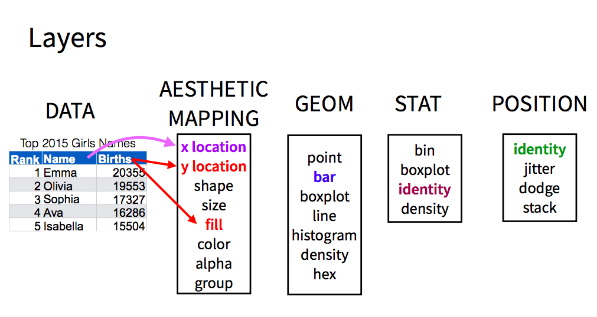

#### Layer 1

```r
library(ggplot2)
df1 <- data.frame(x = rnorm(100), y = rnorm(100))
```

```r
ggplot() + layer(data = df1,
mapping = aes(x, y),
geom = "hex",
)
```

```
Error: Attempted to create layer with no stat.
```

```r
head(mtcars)
```

|  | mpg | cyl | disp | hp | drat | wt | qsec | vs | am | gear | carb |
| --- | --- | --- | --- | --- | --- | --- | --- | --- | --- | --- | --- |
| Mazda RX4 | 21.0 | 6 | 160 | 110 | 3.90 | 2.620 | 16.46 | 0 | 1 | 4 | 4 |
| Mazda RX4 Wag | 21.0 | 6 | 160 | 110 | 3.90 | 2.875 | 17.02 | 0 | 1 | 4 | 4 |
| Datsun 710 | 22.8 | 4 | 108 | 93 | 3.85 | 2.320 | 18.61 | 1 | 1 | 4 | 1 |
| Hornet 4 Drive | 21.4 | 6 | 258 | 110 | 3.08 | 3.215 | 19.44 | 1 | 0 | 3 | 1 |
| Hornet Sportabout | 18.7 | 8 | 360 | 175 | 3.15 | 3.440 | 17.02 | 0 | 0 | 3 | 2 |
| Valiant | 18.1 | 6 | 225 | 105 | 2.76 | 3.460 | 20.22 | 1 | 0 | 3 | 1 |

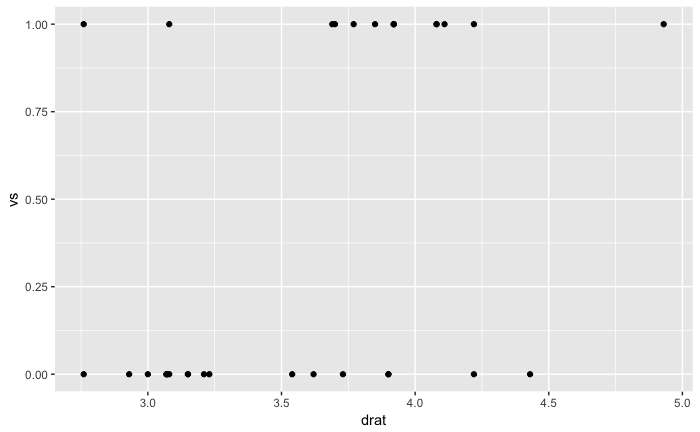

```r
ggplot(mtcars, aes(drat, vs)) +
  geom_point()
```

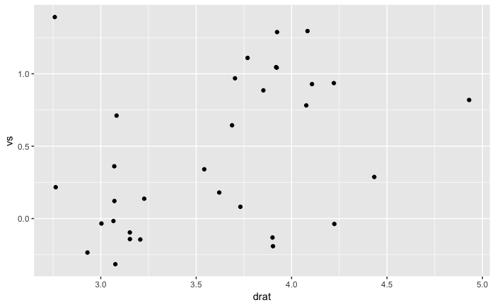

```r
ggplot(mtcars, aes(drat, vs)) +
  geom_jitter()
```

- dodge: positions objects so that there is no overlap at the side.
- stack and fill: positions objetxs so that they are stacked. The stack instructions stacks objects in front of each other such that the largest object on top of one other (to make of equal height that are partitioned by the stacking variable)
- identity: no position adjustment
- jitter: adds a random offset objects so that they don’t overlap.

Data: df1 Mapping: x -> y, y -> x Geom: point Stat: identity Position: identity

#### Layer 2

Data: df2 Mapping: num -> x, height -> y Geom: bar Stat: identity Position: identity

#### Layer 3

Data: df3 Mapping: score -> y; 1 -> x Geom: boxplot Stat: boxplot Position: dodge

#### Layer 4

Data: df4 Mapping: time -> x; dist -> y Geom: line Stat: indentity Position: identity

## Stem and Leaf Plot

```r
prices <- c(379, 425, 450, 450, 499, 529, 535, 535, 545, 599, 665, 675, 699, 699, 725, 725, 745, 799)
stem(prices)
```

[output not shown]

Data: df1 Mapping: x -> y; y -> x Geom: point Stat: identity Position: identity

Data: df2 Mapping: num -> x; height -> y Geom: bar (fill=green) Stat: indentiy Position: identity

Data: df4 Mapping: time -> x; dist -> y Geom: line Stat: identity Position: idenity

```r
df3 <- data.frame(score = rnorm(25, mean = 15, sd = 3))
```

```r
ggplot() + layer(data = df3,
mapping = aes(1, score),
geom = "boxplot",
stat = "boxplot",
position = "dodge") + facet_wrap(~num)
```

```
Error in combine_vars(data, params$plot_env, vars, drop = params$drop) :
  At least one layer must contain all variables used for facetting
```

## Identifying rounding patters

- If the distribution in the histogram doesn’t change when varying the bin width from, lets say 10, to 1, then we could conclude that there are rounding patters.